# The life-changing magic of tidying your projects

# Reading

- Noble (2009)

### Some data management disasters

- *The Economist* (2011), “Video: Keith Baggerly, "When Is Reproducibility an Ethical Issue? Genomics, Personalized Medicine, and Human Error"” (n.d.)
- Herndon, Ash, and Pollin (2014), but you can just read Bailey and Borwein (Jon) (n.d.), Cassidy (n.d.), and/or watch *Reinhart & Rogoff - Growth in a Time of Debt - EXERCISE!* (2019)
- Laskowski (n.d.), Viglione (2020), Pennisi (2020)
- “How Excel May Have Caused Loss of 16,000 Covid Tests in England” (2020)

# Dumpster organization

[figure not shown]

😱 Source: https://pbs.twimg.com/media/DFca5SRXsAAx1NA

- Dump all of your files into one place
- Use search tools to find what you want
- Just assume that things aren’t getting corrupted
- The way many Gen Z students think about their files? (Chin 2021)

# Project organization

- Keep your project self-contained
- Locate files quickly
- Play nicely with version control
- Self-document key relationships between project files

[figure not shown]

Folder organization is your friend. I have top-level folders for teaching, coding, and writing projects. Then each project or collection of projects lives in its own folder. An ‘Archives’ folder is good for tucking old projects out of the way.

# Model 1: Noble (2009)

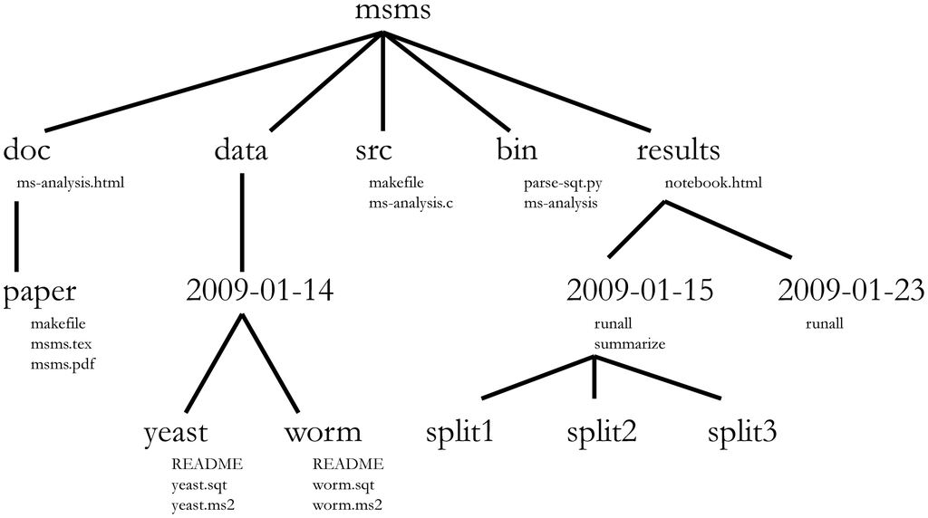

# Model 2: Some of DH’s projects

GitHub repo: https://github.com/dhicks/p_curve  
14 directories, 121 files

```
.
├── DESCRIPTION
├── Makefile
├── README.md
├── _deploy.sh
├── out
│   ├── estimates_meta.png
│   ├── estimates_study.png
│   ├── fig_1_samples_young.png
│   ├── fig_2_young_composite.png
│   ├── fig_3_evidence_severity.png
│   ├── fig_4_evidence_likelihood_zero.png
│   ├── fig_5_evidence_likelihood_mix.png
│   ├── likelihood.tex
│   ├── linearity.png
│   ├── linearity.tex
│   ├── samples_schsp.png
│   ├── samples_simonsohn.png
│   ├── severity.tex
│   ├── slopes.png
│   ├── slopes.tex
│   ├── slopes_scatter.png
│   ├── test.png
│   └── test_out.png
├── p.curve
│   ├── DESCRIPTION
│   ├── NAMESPACE
│   ├── R
│   │   └── p-curve.R
│   ├── man
│   │   ├── draw_samples.Rd
│   │   ├── draw_studies.Rd
│   │   ├── flatten_to_chr.Rd
│   │   ├── likelihood_ratio.Rd
│   │   ├── many_metas.Rd
│   │   ├── p_gap.Rd
│   │   ├── p_value.Rd
│   │   ├── qq_linear.Rd
│   │   ├── qq_plot.Rd
│   │   ├── qq_slope.Rd
│   │   ├── schsp_curve.Rd
│   │   ├── schsp_slope.Rd
│   │   ├── simonsohn_curve.Rd
│   │   ├── t_test.Rd
│   │   ├── young_composite.Rd
│   │   ├── young_curve.Rd
│   │   └── young_slope.Rd
│   └── p.curve.Rproj
├── paper
│   ├── *enviro\ epi
│   │   └── EE\ Submission\ Confirmation\ for\ Young's\ p-value\ plot\ does\ not\ provide\ evidence\ against\ air\ pollution\ hazards.eml
│   ├── Young\ papers.gsheet
│   ├── Young.bib
│   ├── cover\ letter.pdf
│   ├── diff.pdf
│   ├── ehp
│   │   ├── A\ manuscript\ number\ has\ been\ assigned\ to\ Young's\ p-value\ plot\ does\ not\ provide\ evidence\ against\ air\ pollution\ hazards\ -\ [EMID_0ef854c3bb0b5cae].eml
│   │   ├── Decision\ on\ EHP\ Submission\ EHP8013\ -\ [EMID_932e44ac2192c44f].eml
│   │   ├── EHP-CFI-form.pdf
│   │   ├── cover\ letter.txt
│   │   ├── paper_2020-07-31.docx
│   │   └── title\ page.md
│   ├── example-refs.bib
│   ├── fig_1_samples_young.png
│   ├── fig_2_young_composite.png
│   ├── fig_3_evidence_severity.png
│   ├── fig_4_evidence_likelihood_zero.png
│   ├── fig_5_evidence_likelihood_mix.png
│   ├── header.yaml
│   ├── paper.md
│   ├── paper.pdf
│   ├── paper.synctex.gz
│   ├── paper.tex
│   ├── paper.zip
│   ├── paper_20201211.md
│   ├── peerj
│   │   ├── comments.md
│   │   └── peerj.pdf
│   ├── phil\ med
│   │   ├── [philmed]\ Editor\ Decision.eml
│   │   └── [philmed]\ Submission\ Acknowledgement.eml
│   ├── render.R
│   ├── summary.md
│   ├── summary.pdf
│   ├── summary.tex
│   ├── supplement.md
│   ├── supplement.pdf
│   ├── title.md
│   ├── title.pdf
│   ├── vancouver-superscript.csl
│   └── wlpeerj.cls
├── scripts
│   ├── Makefile
│   ├── run_metas.R
│   ├── run_metas.html
│   ├── run_metas_cache
│   │   └── html
│   │       ├── __packages
│   │       ├── power_sim_9c372ce79d0c5f5a133f461070cc735c.RData
│   │       ├── power_sim_9c372ce79d0c5f5a133f461070cc735c.rdb
│   │       ├── power_sim_9c372ce79d0c5f5a133f461070cc735c.rdx
│   │       ├── run\ simulations_b1dfebf278eb300e65b865f76b2893d2.RData
│   │       ├── run\ simulations_b1dfebf278eb300e65b865f76b2893d2.rdb
│   │       ├── run\ simulations_b1dfebf278eb300e65b865f76b2893d2.rdx
│   │       ├── vary_N_sim_7d1d09d59ab04fc75046799fcf7506f9.RData
│   │       ├── vary_N_sim_7d1d09d59ab04fc75046799fcf7506f9.rdb
│   │       └── vary_N_sim_7d1d09d59ab04fc75046799fcf7506f9.rdx
│   ├── run_metas_files
│   │   └── figure-html
│   │       ├── QQ\ linearity\ tests-1.png
│   │       ├── gaps-1.png
│   │       ├── gaps-2.png
│   │       ├── likelihood\ analysis-1.png
│   │       ├── likelihood\ analysis-3.png
│   │       ├── model\ validation-1.png
│   │       ├── model\ validation-2.png
│   │       ├── power_sim-1.png
│   │       ├── power_sim-2.png
│   │       ├── sample\ plots-1.png
│   │       ├── sample\ plots-2.png
│   │       ├── sample\ plots-3.png
│   │       ├── sample\ plots-4.png
│   │       ├── severity\ analysis-1.png
│   │       ├── severity\ analysis-2.png
│   │       ├── slopes-1.png
│   │       ├── slopes-2.png
│   │       ├── slopes-3.png
│   │       ├── slopes-4.png
│   │       ├── slopes-5.png
│   │       ├── slopes-6.png
│   │       ├── slopes-7.png
│   │       ├── unnamed-chunk-2-1.png
│   │       ├── unnamed-chunk-4-1.png
│   │       └── unnamed-chunk-6-1.png
│   └── scripts.Rproj
└── tree.md
```

# Just the directories

```
.
├── out
├── p.curve
│   ├── R
│   └── man
├── paper
│   ├── *enviro\ epi
│   ├── ehp
│   ├── peerj
│   └── phil\ med
└── scripts
    ├── run_metas_cache
    │   └── html
    └── run_metas_files
        └── figure-html
```

- `scripts`, `paper`, and `out`
- `p.curve`, a little package containing the simulation code
- simulation and analysis automatically reproduced: https://dhicks.github.io/p_curve/

# A larger text-mining project

Published paper: https://doi.org/10.1162/qss_a_00150  
GitHub repo: https://github.com/dhicks/orus  
23 directories, 274 files (plus 160k data files)

```
.
├── Makefile
├── ORU\ faculty
│   ├── ORU\ Faculty.docx
│   ├── ORU\ Faculty.html
│   ├── ORU\ Publications.docx
│   ├── ORU\ Publications.fld
│   │   ├── colorschememapping.xml
│   │   ├── filelist.xml
│   │   ├── header.html
│   │   ├── image001.png
│   │   ├── item0001.xml
│   │   ├── props002.xml
│   │   └── themedata.thmx
│   ├── ORU\ Publications.html
│   └── auids.csv
├── ORU\ founding\ dates.gsheet
├── QSS\ forms
│   ├── QSS-Checklist-AcceptedManuscripts.docx
│   ├── QSS_pub_agreement.pdf
│   └── Quantitative\ Science\ Studies\ -\ Decision\ on\ Manuscript\ ID\ QSS-2021-0014.R2.eml
├── R
│   ├── api_keys.R
│   └── hellinger.R
├── auid\ flow.txt
├── data
│   ├── *ORUs\ -\ DSL\ -\ Google\ Drive.webloc
│   ├── 00_UCD_2016.csv
│   ├── 00_UCD_2017.csv
│   ├── 00_UCD_2018.csv
│   ├── 00_faculty_list.html
│   ├── 00_manual_matches.csv
│   ├── 00_publications_list.html
│   ├── 01_departments.csv
│   ├── 01_departments_canonical.csv
│   ├── 01_faculty.Rds
│   ├── 02_pubs.Rds
│   ├── 03_codepartmentals.Rds
│   ├── 03_dropout.Rds
│   ├── 03_matched.Rds
│   ├── 03_unmatched.Rds
│   ├── 04_author_meta.Rds
│   ├── 04_dropouts.Rds
│   ├── 04_genderize
│   ├── 04_namsor.Rds
│   ├── 05_author_meta.Rds
│   ├── 05_dept_dummies.Rds
│   ├── 05_dropouts.Rds
│   ├── 05_layout.Rds
│   ├── 05_matched.Rds
│   ├── 06_author_histories.Rds
│   ├── 07_coauth_count.Rds
│   ├── 07_parsed_histories.Rds
│   ├── 08_phrases.Rds
│   ├── 09_H.Rds
│   ├── 09_atm.csv
│   ├── 09_vocab.tex
│   ├── 10_atm.csv
│   ├── 10_atm_pc.Rds
│   ├── 10_aytm.csv
│   ├── 10_aytm_comp.csv
│   ├── 10_aytm_did.csv
│   ├── 10_model_stats.Rds
│   ├── 10_models.Rds
│   ├── 11_au_dept_xwalk.Rds
│   ├── 11_departments.csv
│   ├── 11_departments_canonical.csv
│   ├── 11_dept_dummies.Rds
│   ├── 11_dept_gamma.Rds
│   ├── 11_dept_term_matrix.Rds
│   ├── 11_oru_gamma.Rds
│   ├── 11_oru_term_matrix.Rds
│   ├── 11_test_train.Rds
│   ├── 12_layout.Rds
│   ├── author_histories [7665 entries exceeds filelimit, not opening dir]
│   ├── authors_meta [6020 entries exceeds filelimit, not opening dir]
│   ├── docs [145144 entries exceeds filelimit, not opening dir]
│   ├── ldatuning_results
│   │   ├── tuningResult_comp.Rds
│   │   ├── tuningResult_comp.docx
│   │   ├── tuningResult_comp.pdf
│   │   ├── tuningResult_did.Rds
│   │   └── tuningResult_did.pdf
│   ├── ldatuning_results-20190415T164055Z-001.zip
│   ├── parsed_blocks [430 entries exceeds filelimit, not opening dir]
│   ├── pubs [282 entries exceeds filelimit, not opening dir]
│   └── temp
├── interdisciplinarity\ project\ notes.gdoc
├── notes.txt
├── paper
│   ├── QSS_a_00150-Hicks_Proof1.pdf
│   ├── apa-6th-edition.csl
│   ├── cover\ letter.txt
│   ├── diff.pdf
│   ├── header.yaml
│   ├── img
│   │   ├── ORU_DAG.png
│   │   ├── cites_regression.png
│   │   ├── coauths_regression.png
│   │   ├── conceptual_model.png
│   │   ├── dept_dist_fixed_reg.png
│   │   ├── dept_dist_reg.png
│   │   ├── dept_gamma.png
│   │   ├── dept_hell_net.png
│   │   ├── dept_hell_net_50.png
│   │   ├── entropies.png
│   │   ├── entropies_selected.png
│   │   ├── entropy_regression.png
│   │   ├── gender.png
│   │   ├── mds.png
│   │   ├── mds_dept.png
│   │   ├── network.png
│   │   ├── oru_dept_entropy.png
│   │   ├── oru_dept_min_dist.png
│   │   ├── oru_dept_min_dist_ridges.png
│   │   ├── oru_dept_network.png
│   │   ├── oru_dept_org_dist.png
│   │   ├── oru_dept_org_dist_ridges.png
│   │   ├── oru_gamma.png
│   │   ├── pub_regression.png
│   │   └── sample.png
│   ├── lit\ review\ notes.txt
│   ├── oru_paper.aux
│   ├── oru_paper.log
│   ├── oru_paper.md
│   ├── oru_paper.out
│   ├── oru_paper.pdf
│   ├── oru_paper.synctex.gz
│   ├── oru_paper.tex
│   ├── oru_paper.zip
│   ├── oru_paper_20200616.pdf
│   ├── oru_paper_20210805.pdf
│   ├── oru_project.bib
│   ├── oru_project.yaml
│   ├── response1.gdoc
│   ├── response1.pdf
│   ├── response2.gdoc
│   ├── response2.pdf
│   ├── scraps
│   │   ├── Hellinger.md
│   │   ├── Holbrook.md
│   │   ├── table.md
│   │   └── table.pdf
│   ├── supplement.md
│   └── supplement.pdf
├── plots
│   ├── 12_beta.tex
│   ├── 12_cites_regression.png
│   ├── 12_coauths_regression.png
│   ├── 12_dept_dist_fixed_reg.png
│   ├── 12_dept_dist_reg.png
│   ├── 12_dept_gamma.png
│   ├── 12_dept_hell_net.png
│   ├── 12_dept_hell_net_50.png
│   ├── 12_dept_topics.png
│   ├── 12_entropies.png
│   ├── 12_entropies_selected.png
│   ├── 12_entropy_regression.png
│   ├── 12_gender.png
│   ├── 12_mds.png
│   ├── 12_mds_dept.png
│   ├── 12_mds_wide.png
│   ├── 12_network.png
│   ├── 12_oru_dept_entropy.png
│   ├── 12_oru_dept_mean_dist.png
│   ├── 12_oru_dept_mean_dist_ridges.png
│   ├── 12_oru_dept_min_dist.png
│   ├── 12_oru_dept_min_dist_ridges.png
│   ├── 12_oru_dept_network.png
│   ├── 12_oru_dept_org_dist.png
│   ├── 12_oru_dept_org_dist_ridges.png
│   ├── 12_oru_entropy.png
│   ├── 12_oru_gamma.png
│   ├── 12_pub_regression.png
│   ├── 12_sample.png
│   └── ORU_DAG.png
├── presentations
│   └── 2019-06-07\ for\ Paul\ Dodd.gslides
├── questions\ for\ jane.md
├── scripts
│   ├── 01_parse_faculty_list.R
│   ├── 02_Scopus_search_results.R
│   ├── 03_match.R
│   ├── 03_matched.csv
│   ├── 04_author_meta.R
│   ├── 05_filtering.R
│   ├── 06_author_histories.R
│   ├── 07_complete_histories.R
│   ├── 08_text_annotation.R
│   ├── 09_build_vocab.R
│   ├── 10_topic_modeling.R
│   ├── 11_depts.R
│   ├── 11_depts.html
│   ├── 12_analysis\ copy.html
│   ├── 12_analysis-matched.html
│   ├── 12_analysis.R
│   ├── 12_analysis.html
│   ├── 12_analysis_cache
│   │   └── html
│   │       ├── __packages
│   │       ├── mds_viz_efd9009c794d667852b2549df2bccf96.RData
│   │       ├── mds_viz_efd9009c794d667852b2549df2bccf96.rdb
│   │       ├── mds_viz_efd9009c794d667852b2549df2bccf96.rdx
│   │       ├── network_c410cd78a4c339cdc4acd1d66c6c5e07.RData
│   │       ├── network_c410cd78a4c339cdc4acd1d66c6c5e07.rdb
│   │       ├── network_c410cd78a4c339cdc4acd1d66c6c5e07.rdx
│   │       ├── silhouette_3170ef648aba325d2ce8c9be48c52e53.RData
│   │       ├── silhouette_3170ef648aba325d2ce8c9be48c52e53.rdb
│   │       ├── silhouette_3170ef648aba325d2ce8c9be48c52e53.rdx
│   │       ├── topic_viz_41d0cb157a88d4ec41810a16e769f5d5.RData
│   │       ├── topic_viz_41d0cb157a88d4ec41810a16e769f5d5.rdb
│   │       └── topic_viz_41d0cb157a88d4ec41810a16e769f5d5.rdx
│   ├── 12_analysis_files
│   │   └── figure-html
│   │       ├── author-dept\ distance-1.png
│   │       ├── author-dept\ distance-2.png
│   │       ├── author-dept\ distance-3.png
│   │       ├── author-dept\ distance-4.png
│   │       ├── author-dept\ distance-5.png
│   │       ├── desc_plots_tabs-1.png
│   │       ├── desc_plots_tabs-2.png
│   │       ├── desc_plots_tabs-3.png
│   │       ├── desc_plots_tabs-4.png
│   │       ├── h3-1.png
│   │       ├── h3-2.png
│   │       ├── h3-3.png
│   │       ├── h3-4.png
│   │       ├── h3-5.png
│   │       ├── h3-6.png
│   │       ├── mds_viz-1.png
│   │       ├── mds_viz-10.png
│   │       ├── mds_viz-11.png
│   │       ├── mds_viz-12.png
│   │       ├── mds_viz-13.png
│   │       ├── mds_viz-14.png
│   │       ├── mds_viz-2.png
│   │       ├── mds_viz-3.png
│   │       ├── mds_viz-4.png
│   │       ├── mds_viz-5.png
│   │       ├── mds_viz-6.png
│   │       ├── mds_viz-7.png
│   │       ├── mds_viz-8.png
│   │       ├── mds_viz-9.png
│   │       ├── network-1.png
│   │       ├── network-2.png
│   │       ├── productivity-1.png
│   │       ├── productivity-2.png
│   │       ├── productivity-3.png
│   │       ├── productivity-4.png
│   │       ├── productivity-5.png
│   │       ├── productivity-6.png
│   │       ├── productivity-7.png
│   │       ├── productivity-8.png
│   │       ├── productivity-9.png
│   │       ├── silhouette-1.png
│   │       ├── topic_models-1.png
│   │       ├── topic_models-10.png
│   │       ├── topic_models-11.png
│   │       ├── topic_models-12.png
│   │       ├── topic_models-13.png
│   │       ├── topic_models-2.png
│   │       ├── topic_models-3.png
│   │       ├── topic_models-4.png
│   │       ├── topic_models-5.png
│   │       ├── topic_models-6.png
│   │       ├── topic_models-7.png
│   │       ├── topic_models-8.png
│   │       ├── topic_models-9.png
│   │       ├── topic_viz-1.png
│   │       └── topic_viz-2.png
│   ├── api_key.R
│   └── scraps
│       ├── 02_parse_pubs_list.R
│       ├── 03_coe_pubs.R
│       ├── 03_match_auids.R
│       ├── 07.R
│       ├── 12_regressions.R
│       ├── BML-CMSI\ deep\ dive.R
│       ├── Hellinger_low_memory.R
│       ├── dept_hell_net.R
│       ├── divergence\ against\ lagged\ distributions.R
│       ├── exploring\ topics.R
│       ├── fractional_authorship.R
│       ├── hellinger.R
│       ├── model_scratch.R
│       ├── multicore.R
│       ├── net_viz.R
│       ├── prcomp.R
│       ├── propensity.R
│       ├── rs_diversity.R
│       ├── spacyr.R
│       ├── topic\ counts\ rather\ than\ entropies.R
│       ├── topic_cosine_sim.R
│       ├── unit-level.R
│       ├── weighted\ regression.R
│       ├── word-topic_distance.R
│       ├── xx_construct_samples.R
│       └── xx_oru_complete_histories.R
└── tree.md
```

# Just the directories

```
.
├── ORU\ faculty
│   └── ORU\ Publications.fld
├── QSS\ forms
├── R
├── data
│   ├── author_histories
│   ├── authors_meta
│   ├── docs
│   ├── ldatuning_results
│   ├── parsed_blocks
│   ├── pubs
│   └── temp
├── paper
│   ├── img
│   └── scraps
├── plots
├── presentations
└── scripts
    ├── 12_analysis_cache
    │   └── html
    ├── 12_analysis_files
    │   └── figure-html
    └── scraps
```

# DH’s Project Template

- https://github.com/dhicks/project_template
- Configured as a GitHub “template,” making it easy to create new repositories for new projects
- Designated folders for data, plots/outputs, and utility functions

# A reminder on paths

- Windows and Unix-based systems write paths differently
- Use `file.path()` or the `here` package to construct paths
- `..` in a path means “go up to the parent folder”
  - so `../data/00_raw_data.csv` goes up one level (eg, from the `scripts` folder), then down to the `data` folder, then the file `00_raw_data.csv`

# References

Bailey, David H., and Jonathan Borwein (Jon). n.d. “The Reinhart-Rogoff Error – or How Not to Excel at Economics.” The Conversation. Accessed May 16, 2020. http://theconversation.com/the-reinhart-rogoff-error-or-how-not-to-excel-at-economics-13646.

Cassidy, John. n.d. “The Reinhart and Rogoff Controversy: A Summing Up.” The New Yorker. Accessed September 27, 2020. https://www.newyorker.com/news/john-cassidy/the-reinhart-and-rogoff-controversy-a-summing-up.

Chin, Monica. 2021. “Students Who Grew up with Search Engines Might Change STEM Education Forever.” The Verge. September 22, 2021. https://www.theverge.com/22684730/students-file-folder-directory-structure-education-gen-z.

Herndon, Thomas, Michael Ash, and Robert Pollin. 2014. “Does High Public Debt Consistently Stifle Economic Growth? A Critique of Reinhart and Rogoff.” *Cambridge Journal of Economics* 38 (2): 257–79. https://doi.org/10.1093/cje/bet075.

“How Excel May Have Caused Loss of 16,000 Covid Tests in England.” 2020. The Guardian. October 5, 2020. http://www.theguardian.com/politics/2020/oct/05/how-excel-may-have-caused-loss-of-16000-covid-tests-in-england.

Laskowski, Kate. n.d. “What to Do When You Don’t Trust Your Data Anymore – Laskowski Lab at UC Davis.” Accessed January 29, 2020. https://laskowskilab.faculty.ucdavis.edu/2020/01/29/retractions/.

Noble, William Stafford. 2009. “A Quick Guide to Organizing Computational Biology Projects.” *PLOS Computational Biology* 5 (7): e1000424. https://doi.org/10.1371/journal.pcbi.1000424.

Pennisi, Elizabeth. 2020. “Prominent Spider Biologist Spun a Web of Questionable Data.” *Science* 367 (6478): 613–14. https://doi.org/10.1126/science.367.6478.613.

*Reinhart & Rogoff - Growth in a Time of Debt - EXERCISE!* 2019. https://www.youtube.com/watch?v=ItGMz0ERvcw.

*The Economist*. 2011. “An Array of Errors,” September 10, 2011. https://www.economist.com/science-and-technology/2011/09/10/an-array-of-errors.

“Video: Keith Baggerly, "When Is Reproducibility an Ethical Issue? Genomics, Personalized Medicine, and Human Error".” n.d. Accessed September 23, 2020. http://www.birs.ca/events/2013/5-day-workshops/13w5083/videos/watch/201308141121-Baggerly.html.

Viglione, Giuliana. 2020. “‘Avalanche’ of Spider-Paper Retractions Shakes Behavioural-Ecology Community.” *Nature*, February. https://doi.org/10.1038/d41586-020-00287-y.